# Veri Madenciliği Final Ödevi

Sevim Özinan

27 01 2021

#SORU 1

**Veri Seti Bilgileri**

Bu veri seti portekiz “Vinho Verde” şarabının kırmızı ve beyaz çeşitleri ile ilgilidir.

**Bağımsız Değişkenler**

fixed acidity : sabit asitlik

volatile acidity : uçucu asitlik

citric acid : sitrik asit

residual sugar : artık şeker

chlorides : klorürler

free sulfur dioxide : serbest kükürt dioksit

total sulfur dioxide : toplam kükürt dioksit

density : yoğunluk

pH : pH

sulphates : sülfatlar

alcohol : alkol

**Bağımlı Değişken**

quality : kalite (0 ile 10 puan arası)

#**Classification Tree**

```
##    type fixed.acidity volatile.acidity citric.acid residual.sugar chlorides
## 1 white           7.0             0.27        0.36           20.7     0.045
## 2 white           6.3             0.30        0.34            1.6     0.049
## 3 white           8.1             0.28        0.40            6.9     0.050
## 4 white           7.2             0.23        0.32            8.5     0.058
## 5 white           7.2             0.23        0.32            8.5     0.058
## 6 white           8.1             0.28        0.40            6.9     0.050
##   free.sulfur.dioxide total.sulfur.dioxide density   pH sulphates alcohol
## 1                  45                  170  1.0010 3.00      0.45     8.8
## 2                  14                  132  0.9940 3.30      0.49     9.5
## 3                  30                   97  0.9951 3.26      0.44    10.1
## 4                  47                  186  0.9956 3.19      0.40     9.9
## 5                  47                  186  0.9956 3.19      0.40     9.9
## 6                  30                   97  0.9951 3.26      0.44    10.1
##   quality
## 1       6
## 2       6
## 3       6
## 4       6
## 5       6
## 6       6
```

Verideki eksik gözlemlere bakalım, varsa temizleyelim.

```r
sum(is.na(data))
```

```
## [1] 38
```

```r
for(i in 1:ncol(data)){
    data[is.na(data[,i]), i] <- mean(data[,i], na.rm = TRUE)
}
sum(is.na(data))
```

```
## [1] 0
```

```r
str(data)
```

```
## 'data.frame':    6497 obs. of  13 variables:
##  $ type                : chr  "white" "white" "white" "white" ...
##  $ fixed.acidity       : num  7 6.3 8.1 7.2 7.2 8.1 6.2 7 6.3 8.1 ...
##  $ volatile.acidity    : num  0.27 0.3 0.28 0.23 0.23 0.28 0.32 0.27 0.3 0.22 ...
##  $ citric.acid         : num  0.36 0.34 0.4 0.32 0.32 0.4 0.16 0.36 0.34 0.43 ...
##  $ residual.sugar      : num  20.7 1.6 6.9 8.5 8.5 6.9 7 20.7 1.6 1.5 ...
##  $ chlorides           : num  0.045 0.049 0.05 0.058 0.058 0.05 0.045 0.045 0.049 0.044 ...
##  $ free.sulfur.dioxide : num  45 14 30 47 47 30 30 45 14 28 ...
##  $ total.sulfur.dioxide: num  170 132 97 186 186 97 136 170 132 129 ...
##  $ density             : num  1.001 0.994 0.995 0.996 0.996 ...
##  $ pH                  : num  3 3.3 3.26 3.19 3.19 3.26 3.18 3 3.3 3.22 ...
##  $ sulphates           : num  0.45 0.49 0.44 0.4 0.4 0.44 0.47 0.45 0.49 0.45 ...
##  $ alcohol             : num  8.8 9.5 10.1 9.9 9.9 10.1 9.6 8.8 9.5 11 ...
##  $ quality             : int  6 6 6 6 6 6 6 6 6 6 ...
```

Yanıt değişkenimiz olan quality değişkenini binary hale getirmek için 6dan az ve çok olmak üzere, low ve high olarak iki kategoriye ayıralım ve qualityFactor olarak isimlendirelim.

```r
qualityFactor <- ifelse(data$quality >= 6, "high", "low")
data <- data.frame(data, qualityFactor)
table(data$qualityFactor)
```

```
##
## high  low
## 4113 2384
```

Şimdi de analizlerde gerekli olmadığından quality ve type değişkenlerini veriden çıkartalım.

```r
data <- data[, -13]
data <- data[, -1]
```

Test ve train kümemizi oluşturalım.

```r
index <- sample(2, nrow(data), replace=TRUE, prob = c(0.80, 0.20))
train <- data[index==1, ]
test <- data[index==2, ]

train$qualityFactor = as.factor(train$qualityFactor)
test$qualityFactor = as.factor(test$qualityFactor)
```

Sınıflandırma ve regresyon ağaçları rpart paketi aracılığıyla oluşturulabilir. Biz de bu paketi kullanarak oluşturalım ve tahmin değerini bulup karar ağacını çizelim.

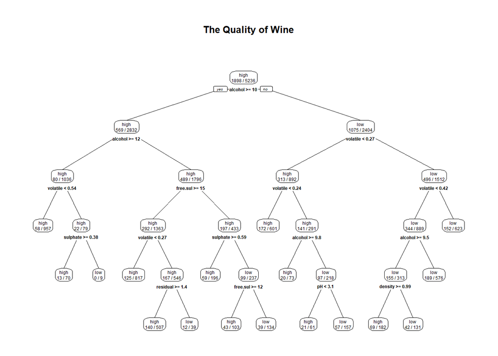

```r
set.seed(1234)
## Rpart modelini oluşturmak, değeri tahmin etmek ve karar ağacını çizmek:
library(rpart.plot)
control <- rpart.control(minsplit = 5L, maxdepth = 5L, minbucket = 5, cp = 0.002, maxsurrogate = 4)
rPartModel <- rpart(qualityFactor~., train, method = "class", control = control)
predict_rpart <- predict(rPartModel, test[, -13], type = "class")
prp(rPartModel, type=2, extra=3, tweak=0.8, main = "The Quality of Wine", compress=TRUE)
```

Tree komutu ile modeli kursaydık,

```r
set.seed(1234)
tree.model1=tree(qualityFactor~., data=train)
summary(tree.model1)
```

```
##
## Classification tree:
## tree(formula = qualityFactor ~ ., data = train)
## Variables actually used in tree construction:
## [1] "alcohol"             "volatile.acidity"    "free.sulfur.dioxide"
## Number of terminal nodes:  5
## Residual mean deviance:  1.078 = 5641 / 5231
## Misclassification error rate: 0.2632 = 1378 / 5236
```

Yukarıdaki çıktı bize bu ağaçla ilgili birçok bilgi vermektedir. Ağacın inşaasında kullanılan değişkenleri, terminal nod sayısı, Default olarak kullanılan deviance ölçütü değeri ve yanlış sınıflandırma oranını görebiliriz.

Bu şekilde oluşturulan bir ağacın test verisi üzerindeki performansını incelersek;

```r
set.seed(1234)
confusionMatrix(predict_rpart, test$qualityFactor)
```

```
## Confusion Matrix and Statistics
##
##           Reference
## Prediction high low
##       high  648 195
##       low   127 291
##
##                Accuracy : 0.7446
##                  95% CI : (0.7196, 0.7685)
##     No Information Rate : 0.6146
##     P-Value [Acc > NIR] : < 2.2e-16
##
##                   Kappa : 0.4465
##
##  Mcnemar's Test P-Value : 0.0001886
##
##             Sensitivity : 0.8361
##             Specificity : 0.5988
##          Pos Pred Value : 0.7687
##          Neg Pred Value : 0.6962
##              Prevalence : 0.6146
##          Detection Rate : 0.5139
##    Detection Prevalence : 0.6685
##       Balanced Accuracy : 0.7174
##
##        'Positive' Class : high
##
```

Şimdi budama (pruning) yapalım. Böylelikle model tahminlerinin varyansını düşüreceğiz ve daha az komplex bir ağaçla çalışabileceğiz.

```r
set.seed(1234)
cv.data=cv.tree(tree.model1,FUN=prune.misclass)
cv.data
```

```
## $size
## [1] 5 3 1
##
## $dev
## [1] 1428 1428 1898
##
## $k
## [1] -Inf    0  260
##
## $method
## [1] "misclass"
##
## attr(,"class")
## [1] "prune"         "tree.sequence"
```

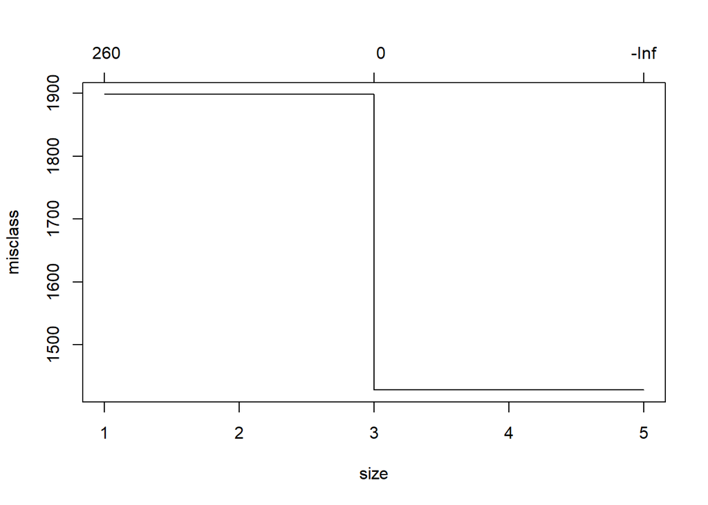

```r
plot(cv.data)
```

Budanan ağacın yapısı ve bu şekilde oluşturulan bir ağacın test verisi üzerindeki performansını inceleyelim;

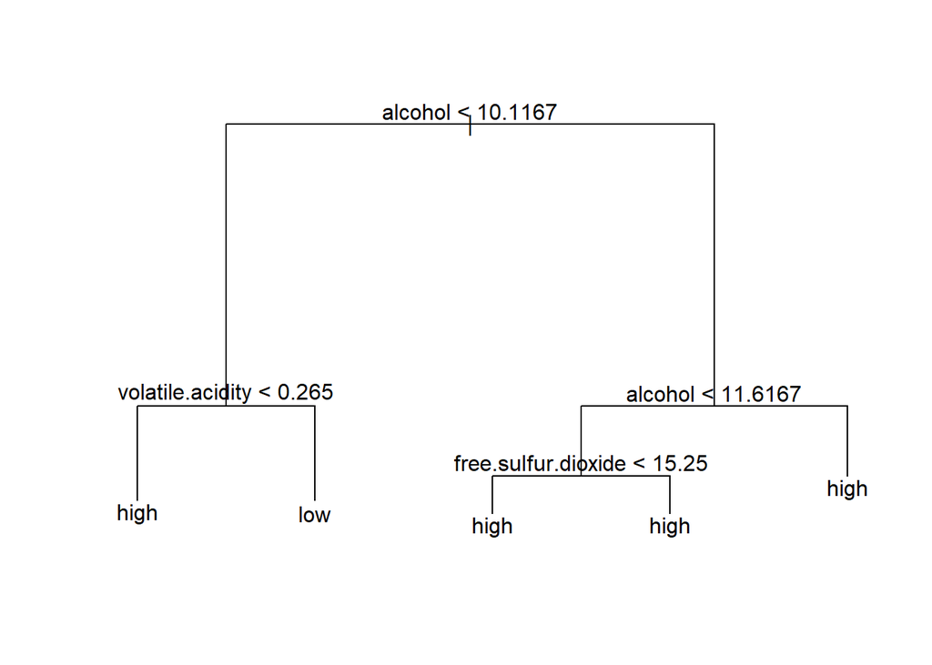

```r
set.seed(1234)
prune.data=prune.misclass(tree.model1,best=4)
plot(prune.data);text(prune.data,pretty=0)
```

```r
prune.data.pred=predict(prune.data,test,type="class")

confusionMatrix(prune.data.pred, test$qualityFactor)
```

```
## Confusion Matrix and Statistics
##
##           Reference
## Prediction high low
##       high  664 230
##       low   111 256
##
##                Accuracy : 0.7296
##                  95% CI : (0.7042, 0.7539)
##     No Information Rate : 0.6146
##     P-Value [Acc > NIR] : < 2.2e-16
##
##                   Kappa : 0.4019
##
##  Mcnemar's Test P-Value : 1.658e-10
##
##             Sensitivity : 0.8568
##             Specificity : 0.5267
##          Pos Pred Value : 0.7427
##          Neg Pred Value : 0.6975
##              Prevalence : 0.6146
##          Detection Rate : 0.5266
##    Detection Prevalence : 0.7090
##       Balanced Accuracy : 0.6918
##
##        'Positive' Class : high
##
```

#**Bagging and Random Forests**

**Bagging**

Bagging için ilk olarak randomForest kütüphanesini indirelim ve training set üzerinde Bagging sınıﬂandırıcımızı kuralım.

Eğer mtray=p(değişken sayısı) alırsak bagging yapmış oluruz.

Default bootstrap sample sayısı 500’dür. İlk olarak default taki gibi çalıştıralım.

```r
library(randomForest)
set.seed(1234)
Bagging.model1=randomForest(qualityFactor~., data=train, mtry=12, importance=TRUE)
Bagging.model1
```

```
##
## Call:
##  randomForest(formula = qualityFactor ~ ., data = train, mtry = 12,      importance = TRUE)
##                Type of random forest: classification
##                      Number of trees: 500
## No. of variables tried at each split: 11
##
##         OOB estimate of  error rate: 17.27%
## Confusion matrix:
##      high  low class.error
## high 2953  385   0.1153385
## low   519 1379   0.2734457
```

Aşağıda Bagging modeline göre değişkenlerin, iki farklı ölçüte göre önemlilik dereceleri sıralanmıştır.

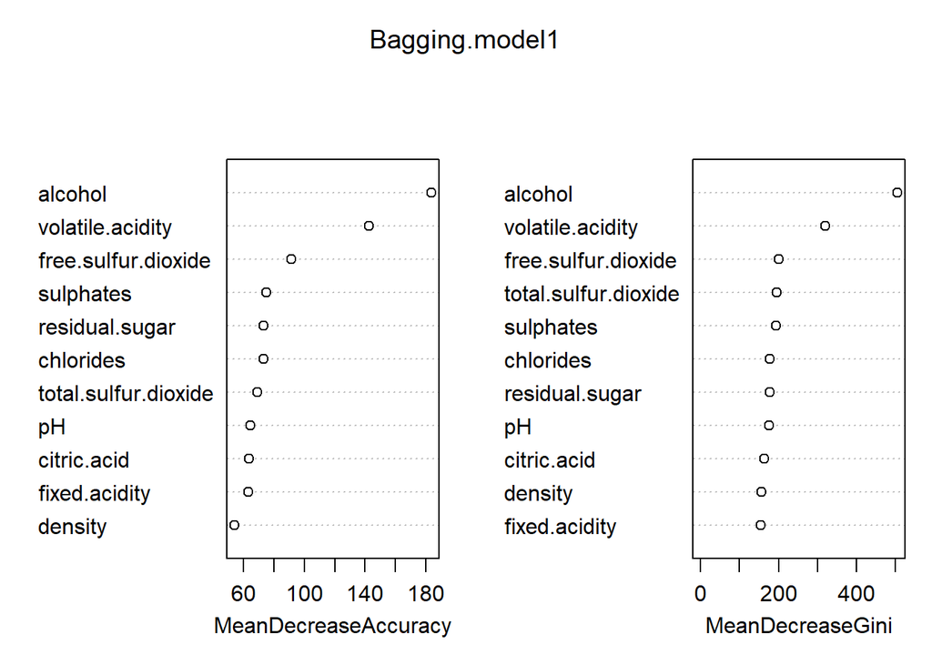

```r
varImpPlot(Bagging.model1)
```

Bu modelin test verisi üzerindeki performansını inceleyelim;

```r
set.seed(1234)
bagg.classTest <-  predict(Bagging.model1,
                         newdata = test,
                          type="class")

confusionMatrix(bagg.classTest, test$qualityFactor)
```

```
## Confusion Matrix and Statistics
##
##           Reference
## Prediction high low
##       high  693 120
##       low    82 366
##
##                Accuracy : 0.8398
##                  95% CI : (0.8184, 0.8596)
##     No Information Rate : 0.6146
##     P-Value [Acc > NIR] : < 2.2e-16
##
##                   Kappa : 0.6569
##
##  Mcnemar's Test P-Value : 0.009233
##
##             Sensitivity : 0.8942
##             Specificity : 0.7531
##          Pos Pred Value : 0.8524
##          Neg Pred Value : 0.8170
##              Prevalence : 0.6146
##          Detection Rate : 0.5496
##    Detection Prevalence : 0.6447
##       Balanced Accuracy : 0.8236
##
##        'Positive' Class : high
##
```

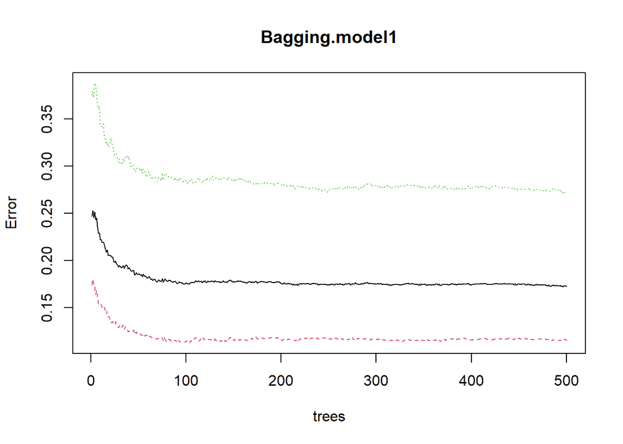

```r
plot(Bagging.model1)
```

Şimdi 500 ağaçlı model yerine 150 ağaçlı model kurarsak ne olur inceleyelim.

```r
set.seed(1234)

Bagging.model2=randomForest(qualityFactor~., data=train, mtry=12, ntree=150, importance=TRUE)
Bagging.model2
```

```
##
## Call:
##  randomForest(formula = qualityFactor ~ ., data = train, mtry = 12,      ntree = 150, importance = TRUE)
##                Type of random forest: classification
##                      Number of trees: 150
## No. of variables tried at each split: 11
##
##         OOB estimate of  error rate: 17.69%
## Confusion matrix:
##      high  low class.error
## high 2953  385   0.1153385
## low   541 1357   0.2850369
```

Bu modelin test verisi üzerindeki performansını inceleyelim;

```r
set.seed(1234)
bagg.classTest2 <-  predict(Bagging.model2,
                         newdata = test,
                          type="class")

confusionMatrix(bagg.classTest2, test$qualityFactor)
```

```
## Confusion Matrix and Statistics
##
##           Reference
## Prediction high low
##       high  691 125
##       low    84 361
##
##                Accuracy : 0.8343
##                  95% CI : (0.8126, 0.8544)
##     No Information Rate : 0.6146
##     P-Value [Acc > NIR] : < 2e-16
##
##                   Kappa : 0.6445
##
##  Mcnemar's Test P-Value : 0.00566
##
##             Sensitivity : 0.8916
##             Specificity : 0.7428
##          Pos Pred Value : 0.8468
##          Neg Pred Value : 0.8112
##              Prevalence : 0.6146
##          Detection Rate : 0.5480
##    Detection Prevalence : 0.6471
##       Balanced Accuracy : 0.8172
##
##        'Positive' Class : high
##
```

Şimdi farklı mtray değerlerini deneyelim. Bunun için r paketinde olan “rf” metodunu kullanalım.

```r
cvcontrol <- trainControl(method="repeatedcv", number = 10,
                          allowParallel=TRUE)
train.rf <- train(as.factor(qualityFactor) ~ .,
                  data=train,
                  method="rf",
                  trControl=cvcontrol,
                  #tuneLength = 3,
                  importance=TRUE)
train.rf
```

```
## Random Forest
##
## 5236 samples
##   11 predictor
##    2 classes: 'high', 'low'
##
## No pre-processing
## Resampling: Cross-Validated (10 fold, repeated 1 times)
## Summary of sample sizes: 4713, 4713, 4712, 4712, 4712, 4713, ...
## Resampling results across tuning parameters:
##
##   mtry  Accuracy   Kappa
##    2    0.8277232  0.6184425
##    6    0.8269580  0.6184903
##   11    0.8198940  0.6040345
##
## Accuracy was used to select the optimal model using the largest value.
## The final value used for the model was mtry = 2.
```

Görüldüğü üzere en yüksek Accuracy değeri mtry = 2 alındığında elde edilmiştir.

Aşağıda Random Forest modeline göre değişkenlerin, mtry = 2 için iki farklı ölçüte göre önemlilik dereceleri sıralanmıştır

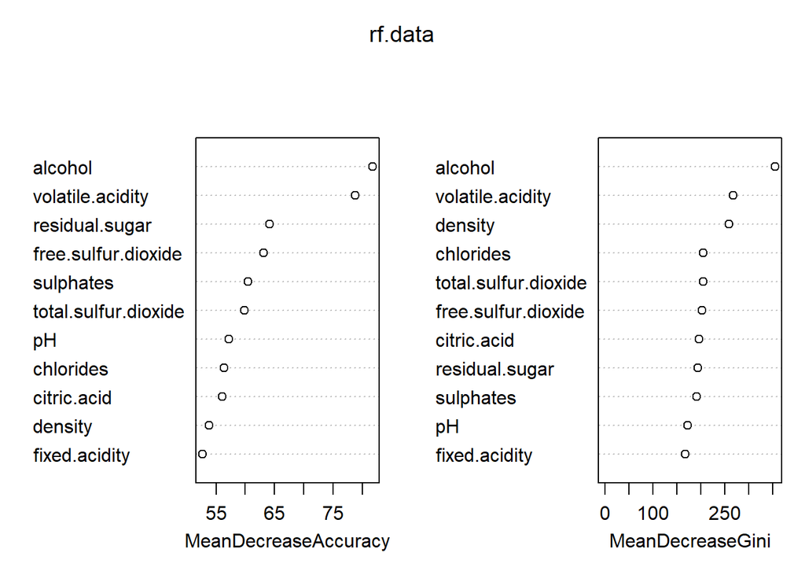

```r
rf.data=randomForest(qualityFactor~.,data=train,mtry=2,importance=TRUE)

varImpPlot(rf.data)
```

Bu modelin test verisi üzerindeki performansını inceleyelim;

```r
set.seed(1234)
rf.classTest <-  predict(train.rf,
                         newdata = test,
                          type="raw")

confusionMatrix(test$qualityFactor,rf.classTest)
```

```
## Confusion Matrix and Statistics
##
##           Reference
## Prediction high low
##       high  698  77
##       low   123 363
##
##                Accuracy : 0.8414
##                  95% CI : (0.82, 0.8611)
##     No Information Rate : 0.6511
##     P-Value [Acc > NIR] : < 2.2e-16
##
##                   Kappa : 0.6592
##
##  Mcnemar's Test P-Value : 0.001463
##
##             Sensitivity : 0.8502
##             Specificity : 0.8250
##          Pos Pred Value : 0.9006
##          Neg Pred Value : 0.7469
##              Prevalence : 0.6511
##          Detection Rate : 0.5535
##    Detection Prevalence : 0.6146
##       Balanced Accuracy : 0.8376
##
##        'Positive' Class : high
##
```

# **Boosting**

Boosting de bagging ve random forest gibi tahmin performansını arttırmaya yönelik bir yaklaşımdır. Onlardan farklı olarak boosting iterative bir yaklaşımdır ve her adımında bir önceki adımdaki performansı geliştirmeye çalışır.

Boosting modelini oluşturalım;

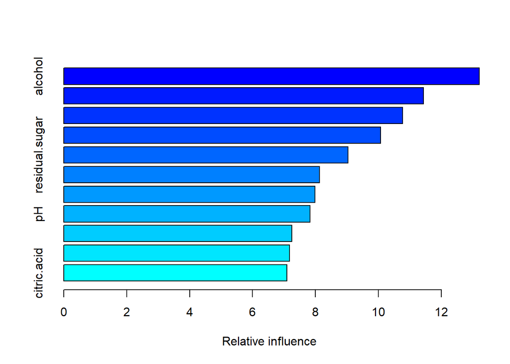

```
##                                       var   rel.inf
## alcohol                           alcohol 13.206213
## total.sulfur.dioxide total.sulfur.dioxide 11.437745
## volatile.acidity         volatile.acidity 10.773466
## density                           density 10.077559
## residual.sugar             residual.sugar  9.035517
## chlorides                       chlorides  8.133505
## free.sulfur.dioxide   free.sulfur.dioxide  7.989237
## pH                                     pH  7.830578
## sulphates                       sulphates  7.245609
## fixed.acidity               fixed.acidity  7.172962
## citric.acid                   citric.acid  7.097610
```

```r
library(gbm)
set.seed(1234)
boost.data=gbm(qualityFactor~.,data=train,distribution="gaussian",n.trees=5000,interaction.depth=4)
summary(boost.data)
```

Boosting modeline göre değişkenlerin önemlilik dereceleri yukarıda sıralanmıştır. alcohol değişkeni kalite belirlenmesinde Boosting modelinde en önemli değişken olarak görülür. Daha sonrasında total.sulfur.dioxide değişkeni en önemli değişkendir.

Bu modelin test verisi üzerindeki performansını inceleyelim;

```r
library(gbm)
yhat.boost=predict(boost.data,newdata=test,n.trees=5000)
mean((yhat.boost-as.numeric(as.factor(test$qualityFactor)))^2)
```

```
## [1] 0.1492202
```

#**Logistic Regression**

Lojistik regresyon, ikili(binary) 1 veya 0 olarak kodlanmış verileri içerir. Bunun için test ve train kümelerimizi yeniden düzenleyelim ve lojistik regresyon modelini kuralım;

```r
train$qualityFactor=ifelse(train$qualityFactor=="high",0,1)
train$qualityFactor=factor(train$qualityFactor)

test$qualityFactor=ifelse(test$qualityFactor=="high",0,1)
test$qualityFactor=factor(test$qualityFactor)

lojistik.model <- glm(qualityFactor~ ., data=train, family=binomial)
summary(lojistik.model)
```

```
##
## Call:
## glm(formula = qualityFactor ~ ., family = binomial, data = train)
##
## Deviance Residuals:
##     Min       1Q   Median       3Q      Max
## -2.6370  -0.8063  -0.4358   0.9020   3.4298
##
## Coefficients:
##                        Estimate Std. Error z value Pr(>|z|)
## (Intercept)          -3.136e+01  4.431e+01  -0.708   0.4791
## fixed.acidity        -8.996e-02  5.662e-02  -1.589   0.1121
## volatile.acidity      4.521e+00  3.090e-01  14.632  < 2e-16 ***
## citric.acid           6.668e-01  2.841e-01   2.347   0.0189 *
## residual.sugar       -8.465e-02  1.883e-02  -4.496 6.93e-06 ***
## chlorides             1.016e+00  1.164e+00   0.872   0.3831
## free.sulfur.dioxide  -1.896e-02  2.851e-03  -6.650 2.94e-11 ***
## total.sulfur.dioxide  7.424e-03  9.909e-04   7.493 6.75e-14 ***
## density               4.224e+01  4.519e+01   0.935   0.3499
## pH                   -5.821e-01  3.329e-01  -1.748   0.0804 .
## sulphates            -2.101e+00  2.999e-01  -7.005 2.46e-12 ***
## alcohol              -8.968e-01  6.611e-02 -13.566  < 2e-16 ***
## ---
## Signif. codes:  0 '***' 0.001 '**' 0.01 '*' 0.05 '.' 0.1 ' ' 1
##
## (Dispersion parameter for binomial family taken to be 1)
##
##     Null deviance: 6857.5  on 5235  degrees of freedom
## Residual deviance: 5378.6  on 5224  degrees of freedom
## AIC: 5402.6
##
## Number of Fisher Scoring iterations: 4
```

Bu modelin train verisi üzerindeki performansını inceleyelim;

```r
library(InformationValue)
set.seed(1234)
predictions<-predict(lojistik.model,type="response")
predtrain<-ifelse(predictions>0.5,1,0)
table(predtrain,train$qualityFactor)
```

```
##
## predtrain    0    1
##         0 2839  839
##         1  499 1059
```

```r
misClassError(train$qualityFactor, predictions, threshold = 0.5)
```

```
## [1] 0.2555
```

Görüldüğü üzere training set üzerindeki sınıflandırma performansı çok iyi değildir. Yanlış sınıflandırma oran 0.26 bulunmuştur.

Şimdi test verisi için tahminlerimizi elde edelim.

```r
predicted <- predict(lojistik.model, test, type="response")  # predicted scores
pred<-ifelse(predicted>0.5,1,0)
table(pred,test$qualityFactor)
```

```
##
## pred   0   1
##    0 657 222
##    1 118 264
```

```r
misClassError(test$qualityFactor, predicted , threshold = 0.5)
```

```
## [1] 0.2696
```

**Optimum Cutoff**

Optimum kesim noktasının bulunması;

```r
library(InformationValue)
optCutOff <- optimalCutoff(train$qualityFactor, predictions)[1]
optCutOff
```

```
## [1] 0.421045
```

Ancak görüldüğü üzere training set için elde edilen optimum cutoff değeri 0.5’ten çok farklı değildir.Aşağıdaki yaklaşımla sensivity ve specifity belli bir oranda tutan cutoff değeri belirlenebilir. İki eğrinin kesim noktası;

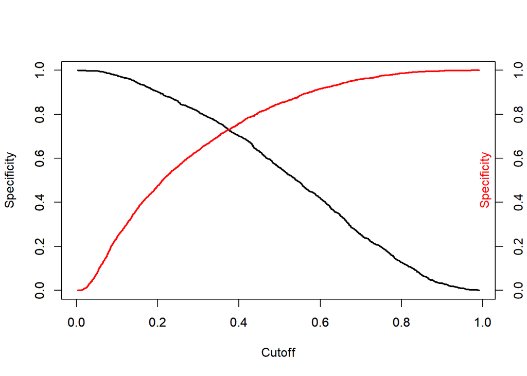

```r
library(ROCR)
predd <- prediction(predictions, train$qualityFactor)
plot(unlist(performance(predd, "sens")@x.values), unlist(performance(predd, "sens")@y.values),
     type="l", lwd=2, ylab="Specificity", xlab="Cutoff")
par(new=TRUE)
plot(unlist(performance(predd, "spec")@x.values), unlist(performance(predd, "spec")@y.values),
     type="l", lwd=2, col='red', ylab="", xlab="")
axis(4, at=seq(0,1,0.2))
mtext("Specificity",side=4, padj=-2, col='red')
```

Görüldüğü gibi bu değerde 0.5’ten çok farklı değildir.

**Receiver Operating Characteristic Curve (ROC)**

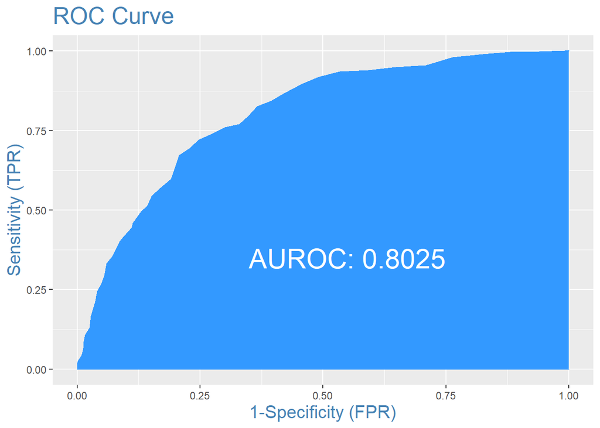

```r
plotROC(test$qualityFactor, predicted)
```

Eğri altında kalan alan ne kadar büyükse o kadar iyidir kurduğumuz model için 0.80 bulunmuştur.

**Concordance**

Genel olarak concordance 1 olarak etiketli olan gözlemlere karşılık tahmin edilen olasılık değerlerinin sıfır olarak kodlu olanlara karşılık tahmin edilenlerin hepsinden yüksek olarak tahmin edilenlerinin oranını verir. Bu oran nekadar yüksek ise model o kadar iyi ayrıştırma yapıyor demektir.

```r
Concordance(test$qualityFactor, predicted)$Concordance
```

```
## [1] 0.8018744
```

Concodance oranı 0.80 bulunmuştur. Bu da modelin iyi ayrıştırma yaptığını gösterir.

**Multicollinearity**

Modelde multicollinearity söz konusu ise bu modelin tahmin performansını etkiler. Bunu da vif komutu ile inceleyebiliriz.

```r
library(car)
vif(lojistik.model)
```

```
##        fixed.acidity     volatile.acidity          citric.acid
##             4.801721             2.098763             1.630669
##       residual.sugar            chlorides  free.sulfur.dioxide
##             7.956313             1.600508             2.234265
## total.sulfur.dioxide              density                   pH
##             3.048013            14.208498             2.554512
##            sulphates              alcohol
##             1.600704             3.794236
```

#SORU 2

Asagida gordugumuz veri setimiz “betonun basinc dayanimiyla” ilgilidir. Bu kavram ozellikle muhendislikte cok onemlidir cunku bir baska tanimla betonda olusan yuk miktarinin sebep olabilecegi kirilmalara ve seklen farklilasmaya karsi gosterdigi direnctir.

Bagimsiz degiskenler:

Cement: Cimento

Blast Furnace Slag: Yuksek firin curufu(yuksek firinlarda demir uretimi esnasinda aciga cikan bir yan urundur)

Fly Ash: Ucucu kul

Water: Su

Superplasticizer: Super plastiklestirici

Coarse Aggregate: Kaba agrega

Fine Aggregate: Ince agrega

Age: Gun (1 ~ 365)

Bagimli degisken: Concrete compressive strength(csMPa): Beton basinc dayanimi(sürekli)

```r
head(dt)
```

```
##   cement  slag flyash water superplasticizer coarseaggregate fineaggregate age
## 1  540.0   0.0      0   162              2.5          1040.0         676.0  28
## 2  540.0   0.0      0   162              2.5          1055.0         676.0  28
## 3  332.5 142.5      0   228              0.0           932.0         594.0 270
## 4  332.5 142.5      0   228              0.0           932.0         594.0 365
## 5  198.6 132.4      0   192              0.0           978.4         825.5 360
## 6  266.0 114.0      0   228              0.0           932.0         670.0  90
##   csMPa
## 1 79.99
## 2 61.89
## 3 40.27
## 4 41.05
## 5 44.30
## 6 47.03
```

```r
str(dt)
```

```
## 'data.frame':    1030 obs. of  9 variables:
##  $ cement          : num  540 540 332 332 199 ...
##  $ slag            : num  0 0 142 142 132 ...
##  $ flyash          : num  0 0 0 0 0 0 0 0 0 0 ...
##  $ water           : num  162 162 228 228 192 228 228 228 228 228 ...
##  $ superplasticizer: num  2.5 2.5 0 0 0 0 0 0 0 0 ...
##  $ coarseaggregate : num  1040 1055 932 932 978 ...
##  $ fineaggregate   : num  676 676 594 594 826 ...
##  $ age             : int  28 28 270 365 360 90 365 28 28 28 ...
##  $ csMPa           : num  80 61.9 40.3 41 44.3 ...
```

# **Bagging and Random Forests**

Bu veride 1030 tane gözlem vardır. Bunların 900 tanesini training set için kullanalım.

```r
train = sample(1:nrow(dt),900)
```

Eğer mtray=p alırsak bagging yapmış oluruz. Default bootstrap sample sayısı 500 dür. İlk olarak default taki gibi çalıştıralım.

```r
set.seed(1234)
bag.dt=randomForest(csMPa~.,data=dt,subset=train,mtry=8,importance=TRUE)
bag.dt
```

```
##
## Call:
##  randomForest(formula = csMPa ~ ., data = dt, mtry = 8, importance = TRUE,      subset = train)
##                Type of random forest: regression
##                      Number of trees: 500
## No. of variables tried at each split: 8
##
##           Mean of squared residuals: 23.12392
##                     % Var explained: 91.6
```

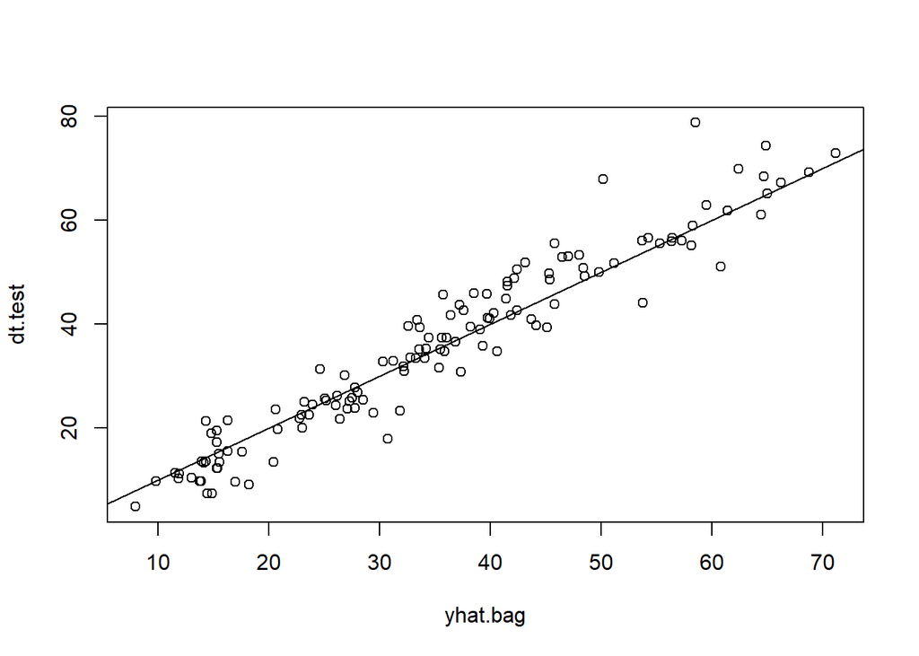

```r
yhat.bag = predict(bag.dt,newdata=dt[-train,])

dt.test=dt[-train,"csMPa"]

plot(yhat.bag, dt.test)
abline(0,1)
```

Görüldüğü gibi MSE değeri 23.12392 bulunmuştur ve toplam varyansın %91.6 sı açıklanmaktadır. Bu MSE ve Explained Variance değerleri out of bag error değerleri kullanılarak elde edilmiştir.

```r
mean((yhat.bag-dt.test)^2)
```

```
## [1] 24.6309
```

Bu model kullanılarak test verisi için elde edilen MSE değeri 24.6309 olarak elde edilmiştir.

Şimdi outof bag error grafiğini çizdirelim.

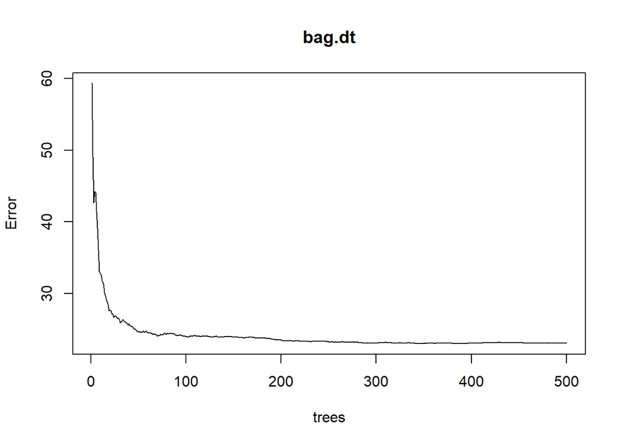

```r
plot(bag.dt)
```

Görüldüğü gibi 100 bootstrap sample bile yeterli gözükmektedir. MSE değerleri 100 den sonra büyük bir değişkenlik göstermemektedir. İlk 150 değere bakıcak olursak bunu görebiliriz.

```r
head(bag.dt$mse,150)
```

```
##   [1] 59.30682 49.15051 42.68835 44.20871 44.08723 41.42805 39.14559 36.10090
##   [9] 33.05310 32.84587 32.63779 31.86166 31.33904 30.20932 29.74437 29.23338
##  [17] 28.88228 28.49099 27.65683 27.62769 27.62001 27.19178 27.18217 26.75051
##  [25] 26.84983 26.90692 26.80189 26.53123 26.65375 26.41282 25.96254 26.17950
##  [33] 26.37553 26.31294 26.10166 26.11775 25.90269 25.87908 25.62342 25.81212
##  [41] 25.59444 25.47473 25.45264 25.35813 25.16475 25.05716 25.04060 24.85934
##  [49] 24.82201 24.63670 24.73333 24.59243 24.62376 24.73141 24.77372 24.60241
##  [57] 24.73104 24.82385 24.66867 24.55861 24.56541 24.53991 24.51041 24.46157
##  [65] 24.36573 24.41308 24.33974 24.34570 24.29716 24.10432 24.18640 24.15969
##  [73] 24.31456 24.28801 24.30788 24.33149 24.44498 24.46100 24.37510 24.47906
##  [81] 24.41828 24.41526 24.44684 24.45624 24.44748 24.41897 24.38601 24.37974
##  [89] 24.23996 24.18425 24.13245 24.19245 24.24740 24.21759 24.18835 24.12970
##  [97] 24.10106 24.08701 24.05494 24.03438 24.00695 23.97226 24.04778 24.07097
## [105] 24.07481 24.10039 24.08591 24.13321 24.12557 24.13891 24.11699 24.11525
## [113] 24.10571 24.09576 24.05237 24.06167 24.08430 24.07213 24.09349 24.06602
## [121] 24.06891 24.11031 24.11175 24.05107 24.03558 23.99675 23.97527 23.95173
## [129] 24.03165 24.05015 24.06252 24.06637 23.97255 23.97556 23.98711 23.97489
## [137] 23.99865 23.96406 23.96796 23.99574 24.03534 24.04484 24.05224 24.06135
## [145] 24.02741 24.00100 24.04669 24.02750 23.98676 23.96892
```

Şimdi 500 ağaçlı model yerine 100 ağaçlı model kurarsak ne olur inceleyelim.

```r
bag.dt=randomForest(csMPa~.,data=dt,subset=train,mtry=8,ntree=100)
yhat.bag = predict(bag.dt,newdata=dt[-train,])
mean((yhat.bag-dt.test)^2)
```

```
## [1] 24.68331
```

Görüldüğü üzere 100 ağaçla da yaklaşık aynı sonucu elde ettik. Şimdi mtry=4 alarak randomforest yapalım.

```r
set.seed(1234)
rf.dt=randomForest(csMPa~.,data=dt,subset=train,mtry=4,importance=TRUE)
yhat.rf = predict(rf.dt,newdata=dt[-train,])
mean((yhat.rf-dt.test)^2)
```

```
## [1] 26.61529
```

Şimdi farklı mtray değerleri için outof bag mse değerleri ile test verisi mse değerlerini karşılaştıralım.

```r
oob.err<-double(8)
test.err<-double(8)

#mtry is no of Variables randomly chosen at each split
for(mtry in 1:8)
{
  rf=randomForest(csMPa ~ . , data = dt , subset = train,mtry=mtry,ntree=500)
  oob.err[mtry] = rf$mse[500] #Error of all Trees fitted

  pred<-predict(rf,dt[-train,]) #Predictions on Test Set for each Tree
  test.err[mtry]= with(dt[-train,], mean( (csMPa - pred)^2)) #Mean Squared Test Error

  cat(mtry," ")

}
```

```
## 1  2  3  4  5  6  7  8
```

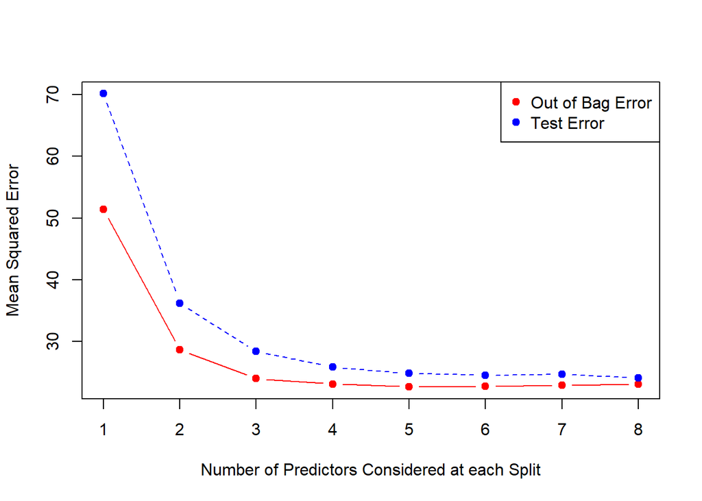

```r
matplot(1:mtry , cbind(oob.err,test.err), pch=19 , col=c("red","blue"),type="b",ylab="Mean Squared Error",xlab="Number of Predictors Considered at each Split")
legend("topright",legend=c("Out of Bag Error","Test Error"),pch=19, col=c("red","blue"))
```

Bu grafikten mtray=8 daha uygun gözüküyor. mtray=8 için hesaplanan test verisi mse değeri

```r
test.err[8]
```

```
## [1] 24.1488
```

Şimdi değişkenlerin önemliliklerini inceleyelim.

```r
importance(rf.dt)
```

```
##                    %IncMSE IncNodePurity
## cement            85.18941     61479.796
## slag              50.74140     16080.231
## flyash            25.93637      9758.201
## water             39.70031     31485.815
## superplasticizer  35.18444     20024.108
## coarseaggregate   31.57435      9621.783
## fineaggregate     43.02257     12838.370
## age              163.66163     81783.968
```

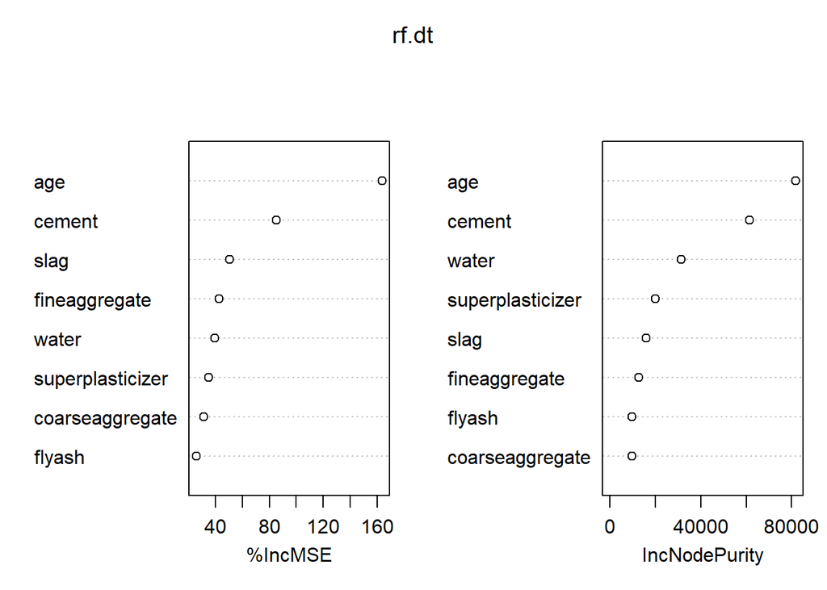

```r
varImpPlot(rf.dt)
```

Burada iki farklı ölçüte göre değişkenlerin önemlilik dereceleri sıralanmıştır. Görüldüğü üzere her iki ölçüte görede age ve cement açık ara daha önemli değişkenlerdir.

# **Boosting**

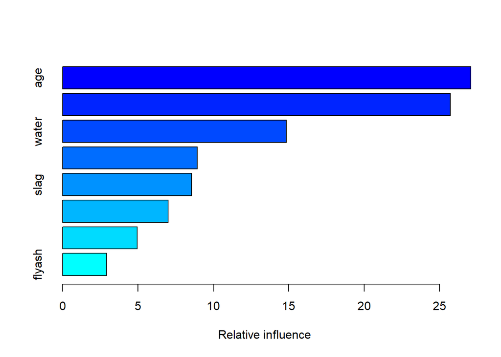

```
##                               var   rel.inf
## age                           age 27.076878
## cement                     cement 25.724700
## water                       water 14.831821
## superplasticizer superplasticizer  8.938559
## slag                         slag  8.553214
## fineaggregate       fineaggregate  6.992121
## coarseaggregate   coarseaggregate  4.951770
## flyash                     flyash  2.930937
```

```r
library(gbm)
set.seed(1234)
boost.dt=gbm(csMPa~.,data=dt[train,],distribution="gaussian",n.trees=5000,interaction.depth=4)
summary(boost.dt)
```

Görüldüğü üzere age, cement ve water en önemli üç değişkenlerdir.

Şimdi modelin test verisi üzerindeki performansını inceleyelim.

```r
set.seed(1234)
yhat.boost=predict(boost.dt,newdata=dt[-train,],n.trees=5000)
mean((yhat.boost-dt.test)^2)
```

```
## [1] 20.83117
```

modelin test verisi üzerindeki performansı 20.83117 bulunmuştur.

#SORU 3

Farklı şarap türlerini kümelemek için bir Şarap veri kümesi kullanacağız. Bu veri seti, İtalya’nın belirli bir bölgesinde yetiştirilen şarapların kimyasal analizinin sonuçlarını içerir. 14 değişkenli ve 178 gözlemden oluşur.

```r
head(wines)
```

```
##   Alcohol Malic_Acid  Ash Ash_Alcanity Magnesium Total_Phenols Flavanoids
## 1   14.23       1.71 2.43         15.6       127          2.80       3.06
## 2   13.20       1.78 2.14         11.2       100          2.65       2.76
## 3   13.16       2.36 2.67         18.6       101          2.80       3.24
## 4   14.37       1.95 2.50         16.8       113          3.85       3.49
## 5   13.24       2.59 2.87         21.0       118          2.80       2.69
## 6   14.20       1.76 2.45         15.2       112          3.27       3.39
##   Nonflavanoid_Phenols Proanthocyanins Color_Intensity  Hue OD280 Proline
## 1                 0.28            2.29            5.64 1.04  3.92    1065
## 2                 0.26            1.28            4.38 1.05  3.40    1050
## 3                 0.30            2.81            5.68 1.03  3.17    1185
## 4                 0.24            2.18            7.80 0.86  3.45    1480
## 5                 0.39            1.82            4.32 1.04  2.93     735
## 6                 0.34            1.97            6.75 1.05  2.85    1450
##   Customer_Segment
## 1                1
## 2                1
## 3                1
## 4                1
## 5                1
## 6                1
```

```r
summary(wines)
```

```
##     Alcohol        Malic_Acid         Ash         Ash_Alcanity
##  Min.   :11.03   Min.   :0.740   Min.   :1.360   Min.   :10.60
##  1st Qu.:12.36   1st Qu.:1.603   1st Qu.:2.210   1st Qu.:17.20
##  Median :13.05   Median :1.865   Median :2.360   Median :19.50
##  Mean   :13.00   Mean   :2.336   Mean   :2.367   Mean   :19.49
##  3rd Qu.:13.68   3rd Qu.:3.083   3rd Qu.:2.558   3rd Qu.:21.50
##  Max.   :14.83   Max.   :5.800   Max.   :3.230   Max.   :30.00
##    Magnesium      Total_Phenols     Flavanoids    Nonflavanoid_Phenols
##  Min.   : 70.00   Min.   :0.980   Min.   :0.340   Min.   :0.1300
##  1st Qu.: 88.00   1st Qu.:1.742   1st Qu.:1.205   1st Qu.:0.2700
##  Median : 98.00   Median :2.355   Median :2.135   Median :0.3400
##  Mean   : 99.74   Mean   :2.295   Mean   :2.029   Mean   :0.3619
##  3rd Qu.:107.00   3rd Qu.:2.800   3rd Qu.:2.875   3rd Qu.:0.4375
##  Max.   :162.00   Max.   :3.880   Max.   :5.080   Max.   :0.6600
##  Proanthocyanins Color_Intensity       Hue             OD280
##  Min.   :0.410   Min.   : 1.280   Min.   :0.4800   Min.   :1.270
##  1st Qu.:1.250   1st Qu.: 3.220   1st Qu.:0.7825   1st Qu.:1.938
##  Median :1.555   Median : 4.690   Median :0.9650   Median :2.780
##  Mean   :1.591   Mean   : 5.058   Mean   :0.9574   Mean   :2.612
##  3rd Qu.:1.950   3rd Qu.: 6.200   3rd Qu.:1.1200   3rd Qu.:3.170
##  Max.   :3.580   Max.   :13.000   Max.   :1.7100   Max.   :4.000
##     Proline       Customer_Segment
##  Min.   : 278.0   Min.   :1.000
##  1st Qu.: 500.5   1st Qu.:1.000
##  Median : 673.5   Median :2.000
##  Mean   : 746.9   Mean   :1.938
##  3rd Qu.: 985.0   3rd Qu.:3.000
##  Max.   :1680.0   Max.   :3.000
```

K-means, denetimsiz bir makine öğrenme algoritmasıdır ve etiketlenmemiş verilerle çalışır. Customer_Segment sütununa ihtiyacımız yok.

```r
wines <- wines[, -14]
```

Şimdi veriyi görselleştirip daha yakından inceleyelim.

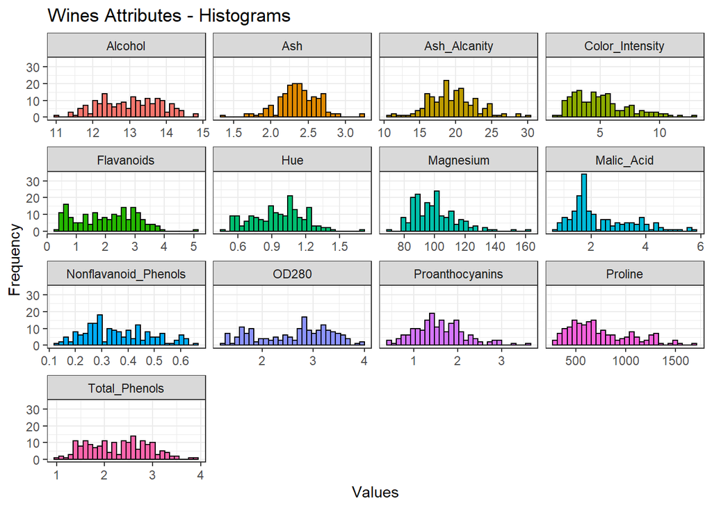

```r
wines %>%
  gather(Attributes, value, 1:13) %>%
  ggplot(aes(x=value, fill=Attributes)) +
  geom_histogram(colour="black", show.legend=FALSE) +
  facet_wrap(~Attributes, scales="free_x") +
  labs(x="Values", y="Frequency",
       title="Wines Attributes - Histograms") +
  theme_bw()
```

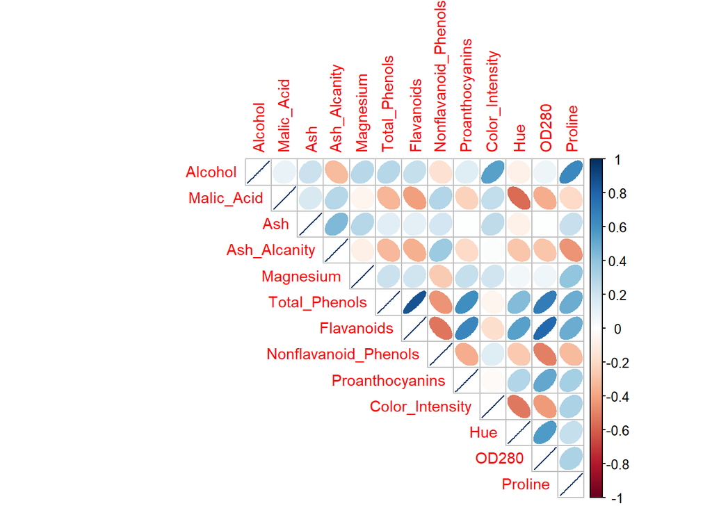

```r
corrplot(cor(wines), type="upper", method="ellipse", tl.cex=0.9)
```

Total_Phenols ve Flavanoids arasında güçlü bir doğrusal ilişki vardır. Doğrusal bir denklem yerleştirerek bu iki değişken arasındaki ilişkiyi modelleyebiliriz.

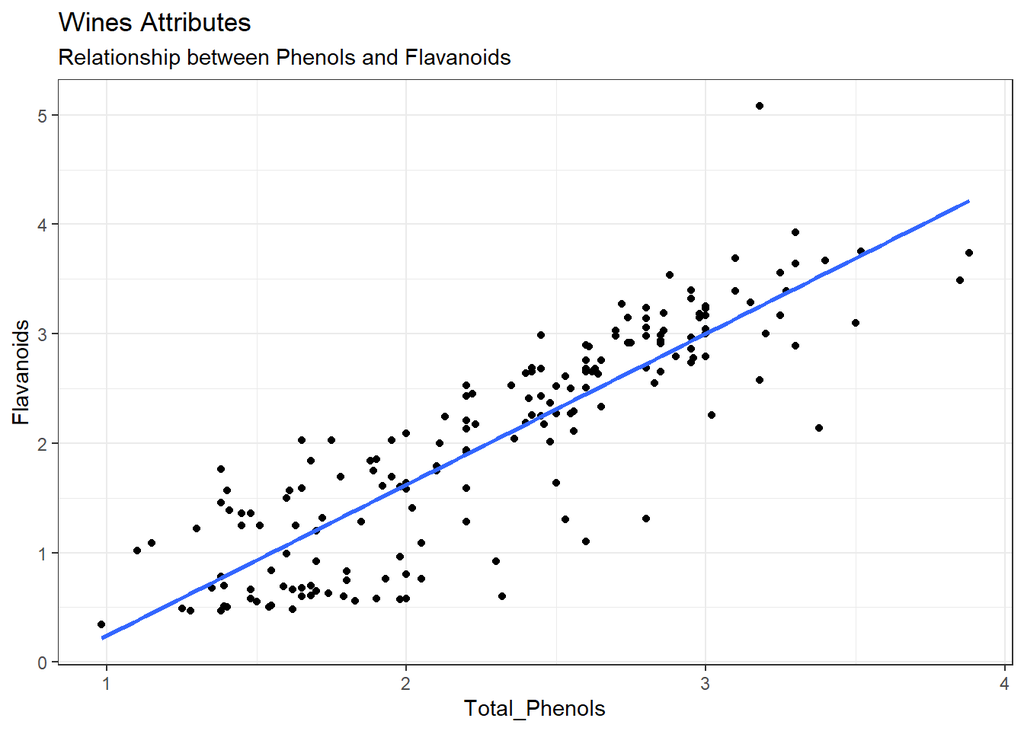

```r
ggplot(wines, aes(x=Total_Phenols, y=Flavanoids)) +
  geom_point() +
  geom_smooth(method="lm", se=FALSE) +
  labs(title="Wines Attributes",
       subtitle="Relationship between Phenols and Flavanoids") +
  theme_bw()
```

Artık keşifsel bir veri analizi yaptığımıza göre, k-means algoritmasını yürütmek için verileri hazırlayabiliriz.

# K-means

Değişkenleri aynı değerler aralığında ifade etmek için normalize etmeliyiz.

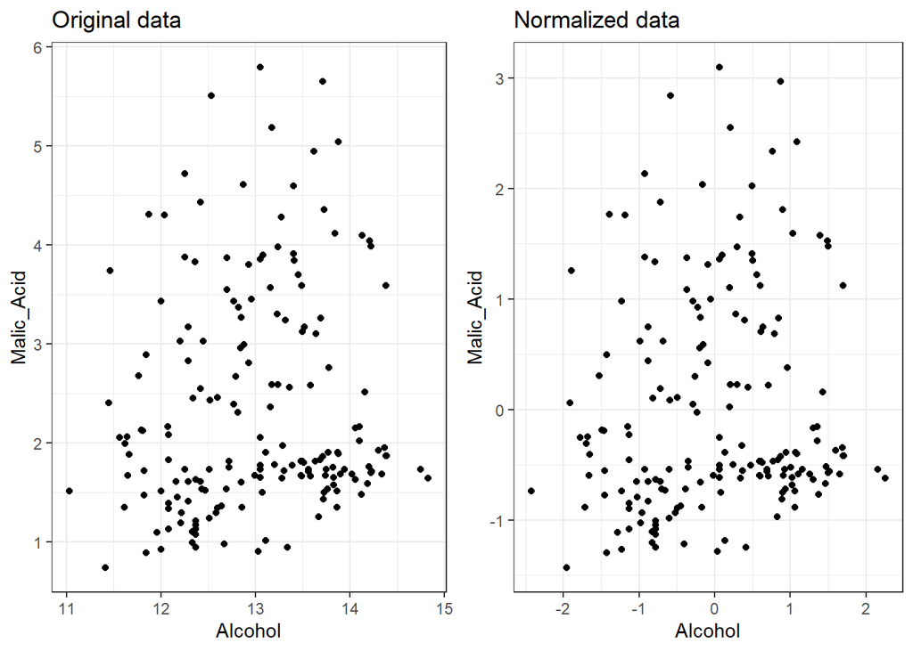

```r
# Normalization
winesNorm <- as.data.frame(scale(wines))

# Original data
p1 <- ggplot(wines, aes(x=Alcohol, y=Malic_Acid)) +
  geom_point() +
  labs(title="Original data") +
  theme_bw()

# Normalized data
p2 <- ggplot(winesNorm, aes(x=Alcohol, y=Malic_Acid)) +
  geom_point() +
  labs(title="Normalized data") +
  theme_bw()

# Subplot
grid.arrange(p1, p2, ncol=2)
```

Normalleştirilmiş verilerdeki noktalar orijinal olanla aynıdır. Değişen tek şey eksenin ölçeğidir.

Veri setimizde k-ortalama algoritmasını iki küme ile çalıştırabilir ve ona wines_k2 diyebiliriz.

```r
# k=2
set.seed(1234)
wines_k2 <- kmeans(winesNorm, centers=2)
```

**cluster : Her noktanın tahsis edildiği kümeyi gösteren bir tamsayı vektörü.**

**centers : Küme merkezlerinin bir matrisi.**

**size : Her kümedeki nokta sayısı.**

```r
#Her noktanın tahsis edildiği küme.
wines_k2$cluster
```

```
##   [1] 1 1 1 1 1 1 1 1 1 1 1 1 1 1 1 1 1 1 1 1 1 1 1 1 1 1 1 1 1 1 1 1 1 1 1 1 1
##  [38] 1 1 1 1 1 1 1 1 1 1 1 1 1 1 1 1 1 1 1 1 1 1 2 2 2 2 1 2 1 1 2 2 1 2 1 2 1
##  [75] 1 2 1 2 1 1 1 1 2 2 1 1 2 2 2 2 2 2 2 1 1 1 2 1 1 1 1 2 2 2 1 2 2 2 2 1 1
## [112] 2 2 2 2 1 2 2 2 2 1 1 2 2 1 2 2 2 2 2 2 2 2 2 2 2 2 2 2 2 2 2 2 2 2 2 2 2
## [149] 2 2 2 2 2 2 2 2 2 2 2 2 2 2 2 2 2 2 2 2 2 2 2 2 2 2 2 2 2 2
```

```r
# küme merkezleri
wines_k2$centers
```

```
##      Alcohol Malic_Acid         Ash Ash_Alcanity  Magnesium Total_Phenols
## 1  0.3248845 -0.3529345  0.05207966   -0.4899811  0.3206911     0.7826625
## 2 -0.3106038  0.3374209 -0.04979045    0.4684435 -0.3065948    -0.7482598
##   Flavanoids Nonflavanoid_Phenols Proanthocyanins Color_Intensity        Hue
## 1  0.8235093           -0.5921337       0.6378483      -0.1024529  0.5633135
## 2 -0.7873111            0.5661058      -0.6098110       0.0979495 -0.5385525
##        OD280    Proline
## 1  0.7146506  0.6051873
## 2 -0.6832374 -0.5785857
```

```r
#her kümedeki nokta sayısı
wines_k2$size
```

```
## [1] 87 91
```

**betweenss : Küme arası karelerin toplamı. Optimal bir bölümlemede, heterojen kümelere sahip olmak istediğimiz için bu oranın olabildiğince yüksek olması beklenir.**

**withinss : Küme başına bir bileşen olmak üzere, küme içi kareler toplamının vektörü. Optimal bir bölümlemede, bu oranın her bir küme için mümkün olduğu kadar düşük olması beklenir,çünkü kümeler içinde homojen olmak istiyoruz.**

**tot.withinss : Küme içi karelerin toplamı.**

**totss : Toplam kareler toplamı.**

```r
# Küme arası kareler toplamı
wines_k2$betweenss
```

```
## [1] 651.56
```

```r
# Küme içi kareler toplamı
wines_k2$withinss
```

```
## [1] 765.0965 884.3435
```

```r
# Küme içi karelerin toplamı
wines_k2$tot.withinss
```

```
## [1] 1649.44
```

```r
# Toplam kareler toplamı
wines_k2$totss
```

```
## [1] 2301
```

Optimal küme sayısını hesaplamak için Grup içi kareler toplamlarının toplamını (yani tot.withinss) kullanabiliriz.

# ** Elbow Method**

```r
kmean_withinss <- function(k) {
    cluster <- kmeans(winesNorm, k)
    return (cluster$tot.withinss)
}
# Set maximum cluster
max_k <-20
set.seed(100)
# Run algorithm over a range of k
wss <- sapply(2:max_k, kmean_withinss)
```

```r
elbow <-data.frame(2:max_k, wss)
```

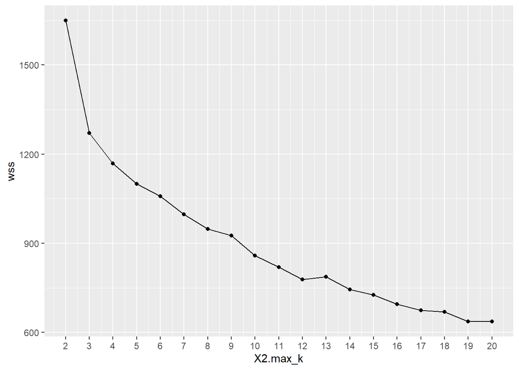

```r
library(ggplot2)
# Plot the graph with gglop
ggplot(elbow, aes(x = X2.max_k, y = wss)) +
    geom_point() +
    geom_line() +
    scale_x_continuous(breaks = seq(1, 20, by = 1))
```

Grafikten optimal k’nin üç olduğunu görebiliriz, burada k daki artışın etkisi azalmaya başlamıştır.

# **Kümenin incelenmesi**

```r
wines_k2 <-kmeans(winesNorm, 3)
wines_k2$cluster
```

```
##   [1] 3 3 3 3 3 3 3 3 3 3 3 3 3 3 3 3 3 3 3 3 3 3 3 3 3 3 3 3 3 3 3 3 3 3 3 3 3
##  [38] 3 3 3 3 3 3 3 3 3 3 3 3 3 3 3 3 3 3 3 3 3 3 1 1 2 1 1 1 1 1 1 1 1 1 1 1 3
##  [75] 1 1 1 1 1 1 1 1 1 2 1 1 1 1 1 1 1 1 1 1 1 3 1 1 1 1 1 1 1 1 1 1 1 1 1 1 1
## [112] 1 1 1 1 1 1 1 2 1 1 3 1 1 1 1 1 1 1 1 2 2 2 2 2 2 2 2 2 2 2 2 2 2 2 2 2 2
## [149] 2 2 2 2 2 2 2 2 2 2 2 2 2 2 2 2 2 2 2 2 2 2 2 2 2 2 2 2 2 2
```

```r
wines_k2$centers
```

```
##      Alcohol Malic_Acid        Ash Ash_Alcanity   Magnesium Total_Phenols
## 1 -0.9234669 -0.3929331 -0.4931257    0.1701220 -0.49032869   -0.07576891
## 2  0.1644436  0.8690954  0.1863726    0.5228924 -0.07526047   -0.97657548
## 3  0.8328826 -0.3029551  0.3636801   -0.6084749  0.57596208    0.88274724
##    Flavanoids Nonflavanoid_Phenols Proanthocyanins Color_Intensity        Hue
## 1  0.02075402          -0.03343924      0.05810161      -0.8993770  0.4605046
## 2 -1.21182921           0.72402116     -0.77751312       0.9388902 -1.1615122
## 3  0.97506900          -0.56050853      0.57865427       0.1705823  0.4726504
##        OD280    Proline
## 1  0.2700025 -0.7517257
## 2 -1.2887761 -0.4059428
## 3  0.7770551  1.1220202
```

```r
wines_k2$size
```

```
## [1] 65 51 62
```